# Intro to R: Data Manipulation and Exploration

Christina Maimone

2018-06-27

# Dates

I highly recommend you use the lubridate package for dates.

```r
library(lubridate)
```

To convert character data to dates, determine the order that the year, month, and day appear in. Then use the lubridate function that corresponds to the order:

```r
mdy("01/31/2018")
```

```
## [1] "2018-01-31"
```

```r
ymd("2018-01-31")
```

```
## [1] "2018-01-31"
```

The delimiters don’t matter. There are functions that have a time component too.

There are also functions to get date components:

```r
d1 <- mdy("01/31/2018")
month(d1)
```

```
## [1] 1
```

```r
year(d1)
```

```
## [1] 2018
```

```r
wday(d1, label=TRUE)
```

```
## [1] Wed
## Levels: Sun < Mon < Tue < Wed < Thu < Fri < Sat
```

You can do math with dates:

```r
today() - d1
```

```
## Time difference of 147 days
```

When plotting, having dates as Date objects will result in a date axis being plotted properly.

# Sorting

The `sort()` function reorders elements:

```r
x <- c(3,6,2,3)
sort(x)
```

```
## [1] 2 3 3 6
```

```r
sort(x, decreasing=TRUE)
```

```
## [1] 6 3 3 2
```

The `order()` function gives you the index positions in sorted order:

```r
order(x)
```

```
## [1] 3 1 4 2
```

```r
x[order(x)]
```

```
## [1] 2 3 3 6
```

```r
order(x, decreasing=TRUE)
```

```
## [1] 2 1 4 3
```

`order()` is useful for arranging data frames:

```r
head(mtcars[order(mtcars$mpg, decreasing=TRUE), c("mpg","hp")])
```

```
##                 mpg  hp
## Toyota Corolla 33.9  65
## Fiat 128       32.4  66
## Honda Civic    30.4  52
## Lotus Europa   30.4 113
## Fiat X1-9      27.3  66
## Porsche 914-2  26.0  91
```

You can give multiple variables to order:

```r
head(mtcars[order(mtcars$cyl, mtcars$mpg, decreasing=TRUE), c("cyl","mpg","hp")])
```

```
##                   cyl  mpg  hp
## Pontiac Firebird    8 19.2 175
## Hornet Sportabout   8 18.7 175
## Merc 450SL          8 17.3 180
## Merc 450SE          8 16.4 180
## Ford Pantera L      8 15.8 264
## Dodge Challenger    8 15.5 150
```

Sorting a table is often useful

```r
sort(table(mtcars$cyl))
```

```
##
##  6  4  8
##  7 11 14
```

# Adding and Removing Columns

```r
df1 <- data.frame(letters=letters,
                  idx=1:26,
                  rand=rnorm(26))
head(df1)
```

```
##   letters idx       rand
## 1       a   1 -0.5918816
## 2       b   2 -0.3633767
## 3       c   3 -0.1644652
## 4       d   4 -0.8072428
## 5       e   5  0.3652817
## 6       f   6  1.9198619
```

You can add a column by naming it and assigning to it:

```r
df1$rand2 <- sample(1:26, 26, replace=TRUE)
head(df1)
```

```
##   letters idx       rand rand2
## 1       a   1 -0.5918816     8
## 2       b   2 -0.3633767     7
## 3       c   3 -0.1644652    22
## 4       d   4 -0.8072428    17
## 5       e   5  0.3652817    23
## 6       f   6  1.9198619    21
```

Or using the cbind function for multiple columns at once (or data frames) – they need to have the same number of rows.

```r
df2 <- cbind(df1, positive1=df1$rand > 0,
             vowel=df1$letters %in% c('a','e','i','o','u'))
head(df2)
```

```
##   letters idx       rand rand2 positive1 vowel
## 1       a   1 -0.5918816     8     FALSE  TRUE
## 2       b   2 -0.3633767     7     FALSE FALSE
## 3       c   3 -0.1644652    22     FALSE FALSE
## 4       d   4 -0.8072428    17     FALSE FALSE
## 5       e   5  0.3652817    23      TRUE  TRUE
## 6       f   6  1.9198619    21      TRUE FALSE
```

```r
df2 <- data.frame(l1=LETTERS, l2="cats")
head(df2)
```

```
##   l1   l2
## 1  A cats
## 2  B cats
## 3  C cats
## 4  D cats
## 5  E cats
## 6  F cats
```

```r
head(cbind(df1, df2))
```

```
##   letters idx       rand rand2 l1   l2
## 1       a   1 -0.5918816     8  A cats
## 2       b   2 -0.3633767     7  B cats
## 3       c   3 -0.1644652    22  C cats
## 4       d   4 -0.8072428    17  D cats
## 5       e   5  0.3652817    23  E cats
## 6       f   6  1.9198619    21  F cats
```

To remove a column, resave the data frame with the column(s) excluded (or just select the ones you want)

```r
df1 <- df1[,-4]
head(df1)
```

```
##   letters idx       rand
## 1       a   1 -0.5918816
## 2       b   2 -0.3633767
## 3       c   3 -0.1644652
## 4       d   4 -0.8072428
## 5       e   5  0.3652817
## 6       f   6  1.9198619
```

# Subset

The `subset()` function lets you select rows and columns you want to keep:

```r
subset(data.frame,
       subset=condition for rows to keep,
       select=columns to keep)
```

You don’t have to quote variable names or prefix with name of the data frame

```r
subset(mtcars,
       subset=cyl==6,
       select=c(cyl, mpg, hp))
```

```
##                cyl  mpg  hp
## Mazda RX4        6 21.0 110
## Mazda RX4 Wag    6 21.0 110
## Hornet 4 Drive   6 21.4 110
## Valiant          6 18.1 105
## Merc 280         6 19.2 123
## Merc 280C        6 17.8 123
## Ferrari Dino     6 19.7 175
```

You don’t have to use both subset and select arguments – you can omit one of them if not relevant.

# Recoding/Replacing Values

To recode a variable, you could make a new column, or overwrite the existing one entirely:

```r
mtcars2 <- mtcars
mtcars2$mpg <- round(mtcars2$mpg)
```

If you just want to replace part of a column (or vector), you can assign to a subset

```r
df1 <- data.frame(letters=letters,
                  idx=1:26,
                  rand=rnorm(26),
                  stringsAsFactors = FALSE)
head(df1)
```

```
##   letters idx       rand
## 1       a   1 -1.6893672
## 2       b   2 -1.5841479
## 3       c   3  0.1653742
## 4       d   4  0.3414706
## 5       e   5  1.8608792
## 6       f   6  1.2073494
```

```r
df1$letters[df1$letters %in% c("a","e","i","o","u")] <- "*"
head(df1)
```

```
##   letters idx       rand
## 1       *   1 -1.6893672
## 2       b   2 -1.5841479
## 3       c   3  0.1653742
## 4       d   4  0.3414706
## 5       *   5  1.8608792
## 6       f   6  1.2073494
```

There’s also a `recode()` function in the `car` library. You specify the reassignment of values in a string

```r
library(car)
df1 <- data.frame(letters=letters,
                  idx=1:26,
                  rand=rnorm(26),
                  stringsAsFactors = FALSE)
df1$letters <- recode(df1$letters, 'c("a","e","i","o","u")="*"')
df1$letters
```

```
##  [1] "*" "b" "c" "d" "*" "f" "g" "h" "*" "j" "k" "l" "m" "n" "*" "p" "q"
## [18] "r" "s" "t" "*" "v" "w" "x" "y" "z"
```

The `ifelse` function, covered in Part 6, is also useful for recoding.

# Aggregating

To compute summary statistics by groups in the data, one option is to use the `aggregate` function:

```r
aggregate(mtcars$mpg, by=list(cyl=mtcars$cyl), mean)
```

```
##   cyl        x
## 1   4 26.66364
## 2   6 19.74286
## 3   8 15.10000
```

```r
aggregate(mtcars$mpg, by=list(cyl=mtcars$cyl, gear=mtcars$gear), mean)
```

```
##   cyl gear      x
## 1   4    3 21.500
## 2   6    3 19.750
## 3   8    3 15.050
## 4   4    4 26.925
## 5   6    4 19.750
## 6   4    5 28.200
## 7   6    5 19.700
## 8   8    5 15.400
```

# Apply Functions

The apply functions can also be used for computing aggregates by groups. There are multiply apply functions that will map/apply a function over a vector, data frame, list, etc. and create an output vector, data frame, list of the results. Two common apply functions are `apply()` for applying to the rows or columns of a data frame or matrix, and `tapply()` for applying a function to a vector based on groups determined by another vector:

```r
df2<-data.frame(r1=rnorm(10), r2=rnorm(10), r3=rnorm(10))
apply(df2, 1, max) # 1 is for rows
```

```
##  [1] -0.1930995  0.7680091  0.1173940  1.9946033 -0.1268868 -1.5032977
##  [7]  1.0711891  0.1661895  2.3810246 -0.4257542
```

```r
apply(df2, 2, max) # 2 is for columns
```

```
##       r1       r2       r3
## 0.117394 2.381025 1.908867
```

You could use apply on a subset of columns too, which is useful with data frames that may have mixed columns, when you just want to work with certain column types:

```r
apply(df2[,1:2], 1, max)
```

```
##  [1] -0.8796914 -0.9146165  0.1173940  1.9946033 -1.0596152 -1.5662568
##  [7] -0.3607464  0.1661895  2.3810246 -0.4257542
```

`tapply()` instead of taking 1 for rows or 2 for margins, takes another vector that determines groups:

```r
tapply(mtcars$mpg, mtcars$cyl, mean)
```

```
##        4        6        8
## 26.66364 19.74286 15.10000
```

The first argument can only be a single vector though, not a data frame or matrix.

# Statistics

## Setup

For the sections below, we’ll use a built in data set, `mtcars`

```r
data(mtcars)
head(mtcars)
```

```
##                    mpg cyl disp  hp drat    wt  qsec vs am gear carb
## Mazda RX4         21.0   6  160 110 3.90 2.620 16.46  0  1    4    4
## Mazda RX4 Wag     21.0   6  160 110 3.90 2.875 17.02  0  1    4    4
## Datsun 710        22.8   4  108  93 3.85 2.320 18.61  1  1    4    1
## Hornet 4 Drive    21.4   6  258 110 3.08 3.215 19.44  1  0    3    1
## Hornet Sportabout 18.7   8  360 175 3.15 3.440 17.02  0  0    3    2
## Valiant           18.1   6  225 105 2.76 3.460 20.22  1  0    3    1
```

## Tables

We’ve covered some simple measures before, like `mean` and `summary`:

```r
mean(mtcars$mpg)
```

```
## [1] 20.09062
```

```r
summary(mtcars$mpg)
```

```
##    Min. 1st Qu.  Median    Mean 3rd Qu.    Max.
##   10.40   15.43   19.20   20.09   22.80   33.90
```

And we’ve made frequency tables of values:

```r
table(mtcars$gear)
```

```
##
##  3  4  5
## 15 12  5
```

Although we can go beyond 1 variable to 2 or 3:

```r
table(mtcars$gear, mtcars$am) # rows, cols
```

```
##
##      0  1
##   3 15  0
##   4  4  8
##   5  0  5
```

`ftable` makes output for 3 dimension tables a bit easier to read

```r
ftable(mtcars$gear, mtcars$am, mtcars$cyl) # rows, subrows, columns
```

```
##       4  6  8
##
## 3 0   1  2 12
##   1   0  0  0
## 4 0   2  2  0
##   1   6  2  0
## 5 0   0  0  0
##   1   2  1  2
```

or proportion tables:

```r
prop.table(table(mtcars$gear))
```

```
##
##       3       4       5
## 0.46875 0.37500 0.15625
```

## Correlation

Correlation between two variables

```r
cor(mtcars$mpg, mtcars$disp)
```

```
## [1] -0.8475514
```

Or all pairwise comparisons:

```r
cor(mtcars)
```

```
##             mpg        cyl       disp         hp        drat         wt
## mpg   1.0000000 -0.8521620 -0.8475514 -0.7761684  0.68117191 -0.8676594
## cyl  -0.8521620  1.0000000  0.9020329  0.8324475 -0.69993811  0.7824958
## disp -0.8475514  0.9020329  1.0000000  0.7909486 -0.71021393  0.8879799
## hp   -0.7761684  0.8324475  0.7909486  1.0000000 -0.44875912  0.6587479
## drat  0.6811719 -0.6999381 -0.7102139 -0.4487591  1.00000000 -0.7124406
## wt   -0.8676594  0.7824958  0.8879799  0.6587479 -0.71244065  1.0000000
## qsec  0.4186840 -0.5912421 -0.4336979 -0.7082234  0.09120476 -0.1747159
## vs    0.6640389 -0.8108118 -0.7104159 -0.7230967  0.44027846 -0.5549157
## am    0.5998324 -0.5226070 -0.5912270 -0.2432043  0.71271113 -0.6924953
## gear  0.4802848 -0.4926866 -0.5555692 -0.1257043  0.69961013 -0.5832870
## carb -0.5509251  0.5269883  0.3949769  0.7498125 -0.09078980  0.4276059
##             qsec         vs          am       gear        carb
## mpg   0.41868403  0.6640389  0.59983243  0.4802848 -0.55092507
## cyl  -0.59124207 -0.8108118 -0.52260705 -0.4926866  0.52698829
## disp -0.43369788 -0.7104159 -0.59122704 -0.5555692  0.39497686
## hp   -0.70822339 -0.7230967 -0.24320426 -0.1257043  0.74981247
## drat  0.09120476  0.4402785  0.71271113  0.6996101 -0.09078980
## wt   -0.17471588 -0.5549157 -0.69249526 -0.5832870  0.42760594
## qsec  1.00000000  0.7445354 -0.22986086 -0.2126822 -0.65624923
## vs    0.74453544  1.0000000  0.16834512  0.2060233 -0.56960714
## am   -0.22986086  0.1683451  1.00000000  0.7940588  0.05753435
## gear -0.21268223  0.2060233  0.79405876  1.0000000  0.27407284
## carb -0.65624923 -0.5696071  0.05753435  0.2740728  1.00000000
```

Alternatively, covariance

```r
cov(mtcars)
```

```
##              mpg         cyl        disp          hp         drat
## mpg    36.324103  -9.1723790  -633.09721 -320.732056   2.19506351
## cyl    -9.172379   3.1895161   199.66028  101.931452  -0.66836694
## disp -633.097208 199.6602823 15360.79983 6721.158669 -47.06401915
## hp   -320.732056 101.9314516  6721.15867 4700.866935 -16.45110887
## drat    2.195064  -0.6683669   -47.06402  -16.451109   0.28588135
## wt     -5.116685   1.3673710   107.68420   44.192661  -0.37272073
## qsec    4.509149  -1.8868548   -96.05168  -86.770081   0.08714073
## vs      2.017137  -0.7298387   -44.37762  -24.987903   0.11864919
## am      1.803931  -0.4657258   -36.56401   -8.320565   0.19015121
## gear    2.135685  -0.6491935   -50.80262   -6.358871   0.27598790
## carb   -5.363105   1.5201613    79.06875   83.036290  -0.07840726
##               wt         qsec           vs           am        gear
## mpg   -5.1166847   4.50914919   2.01713710   1.80393145   2.1356855
## cyl    1.3673710  -1.88685484  -0.72983871  -0.46572581  -0.6491935
## disp 107.6842040 -96.05168145 -44.37762097 -36.56401210 -50.8026210
## hp    44.1926613 -86.77008065 -24.98790323  -8.32056452  -6.3588710
## drat  -0.3727207   0.08714073   0.11864919   0.19015121   0.2759879
## wt     0.9573790  -0.30548161  -0.27366129  -0.33810484  -0.4210806
## qsec  -0.3054816   3.19316613   0.67056452  -0.20495968  -0.2804032
## vs    -0.2736613   0.67056452   0.25403226   0.04233871   0.0766129
## am    -0.3381048  -0.20495968   0.04233871   0.24899194   0.2923387
## gear  -0.4210806  -0.28040323   0.07661290   0.29233871   0.5443548
## carb   0.6757903  -1.89411290  -0.46370968   0.04637097   0.3266129
##             carb
## mpg  -5.36310484
## cyl   1.52016129
## disp 79.06875000
## hp   83.03629032
## drat -0.07840726
## wt    0.67579032
## qsec -1.89411290
## vs   -0.46370968
## am    0.04637097
## gear  0.32661290
## carb  2.60887097
```

## Testing Differences

### T-test

Do manual and automatic transmission cars have different mean miles per gallon?

```r
t.test(mtcars$mpg~mtcars$am)
```

```
##
##  Welch Two Sample t-test
##
## data:  mtcars$mpg by mtcars$am
## t = -3.7671, df = 18.332, p-value = 0.001374
## alternative hypothesis: true difference in means is not equal to 0
## 95 percent confidence interval:
##  -11.280194  -3.209684
## sample estimates:
## mean in group 0 mean in group 1
##        17.14737        24.39231
```

Think of `~` as “as a function of”. So above, MPG as a function of transmission, meaning grouped by or explained by.

We don’t have to use the formula syntax. We can send data for two different groups:

```r
t.test(mtcars$mpg[mtcars$am==0], mtcars$mpg[mtcars$am==1])
```

[output not shown]

In addition to the printout, you can get the various parts of the results

```r
t1 <- t.test(mtcars$mpg~mtcars$am)
names(t1)
```

```
## [1] "statistic"   "parameter"   "p.value"     "conf.int"    "estimate"
## [6] "null.value"  "alternative" "method"      "data.name"
```

```r
t1$statistic
```

```
##         t
## -3.767123
```

### Regression

Let’s predict MPG using a linear model. First, a simple bivariate regression – just one explanatory variable.

Basic syntax is

```r
lm(y ~ x1 + x2 + x3, data=df_name)
```

Example:

```r
lm(mpg ~ hp, data=mtcars)
```

```
##
## Call:
## lm(formula = mpg ~ hp, data = mtcars)
##
## Coefficients:
## (Intercept)           hp
##    30.09886     -0.06823
```

Default output isn’t much. You get a lot more with `summary`:

```r
r1 <- lm(mpg ~ hp, data=mtcars)
summary(r1)
```

```
##
## Call:
## lm(formula = mpg ~ hp, data = mtcars)
##
## Residuals:
##     Min      1Q  Median      3Q     Max
## -5.7121 -2.1122 -0.8854  1.5819  8.2360
##
## Coefficients:
##             Estimate Std. Error t value Pr(>|t|)
## (Intercept) 30.09886    1.63392  18.421  < 2e-16 ***
## hp          -0.06823    0.01012  -6.742 1.79e-07 ***
## ---
## Signif. codes:  0 '***' 0.001 '**' 0.01 '*' 0.05 '.' 0.1 ' ' 1
##
## Residual standard error: 3.863 on 30 degrees of freedom
## Multiple R-squared:  0.6024, Adjusted R-squared:  0.5892
## F-statistic: 45.46 on 1 and 30 DF,  p-value: 1.788e-07
```

Note that a constant (Intercept) term was added automatically.

As above, you can pull out the individual components as needed

```r
names(r1)
```

```
##  [1] "coefficients"  "residuals"     "effects"       "rank"
##  [5] "fitted.values" "assign"        "qr"            "df.residual"
##  [9] "xlevels"       "call"          "terms"         "model"
```

### Visualizing the result

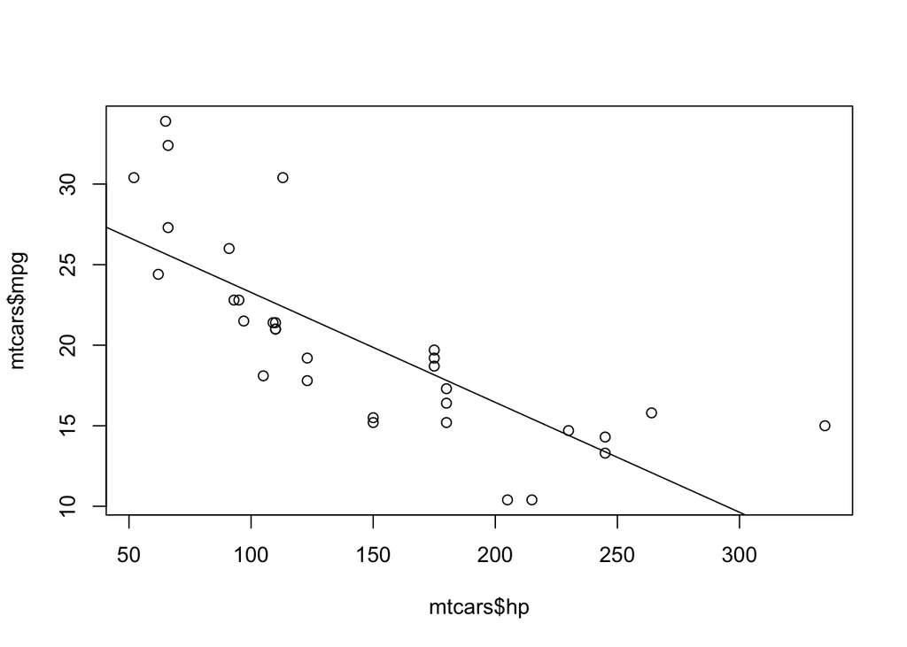

```r
plot(mtcars$mpg ~ mtcars$hp)
abline(r1)
```

Label points with

```r
identify(mtcars$hp, mtcars$mpg,
         labels=rownames(mtcars))
```

And visualizing diagnostics:

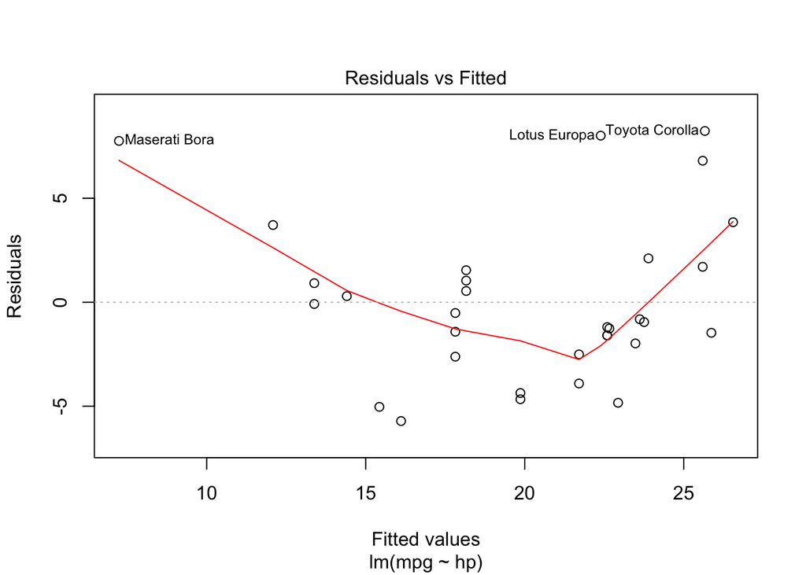

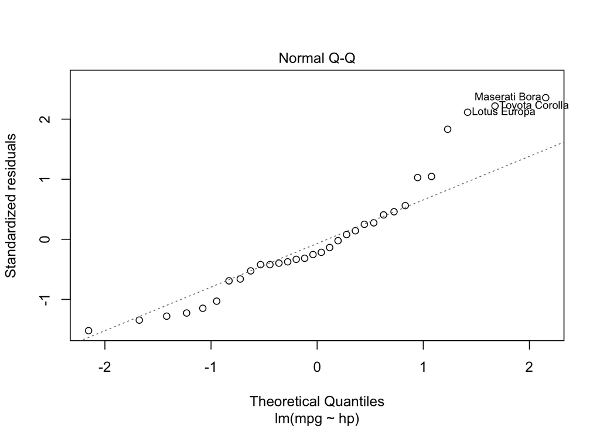

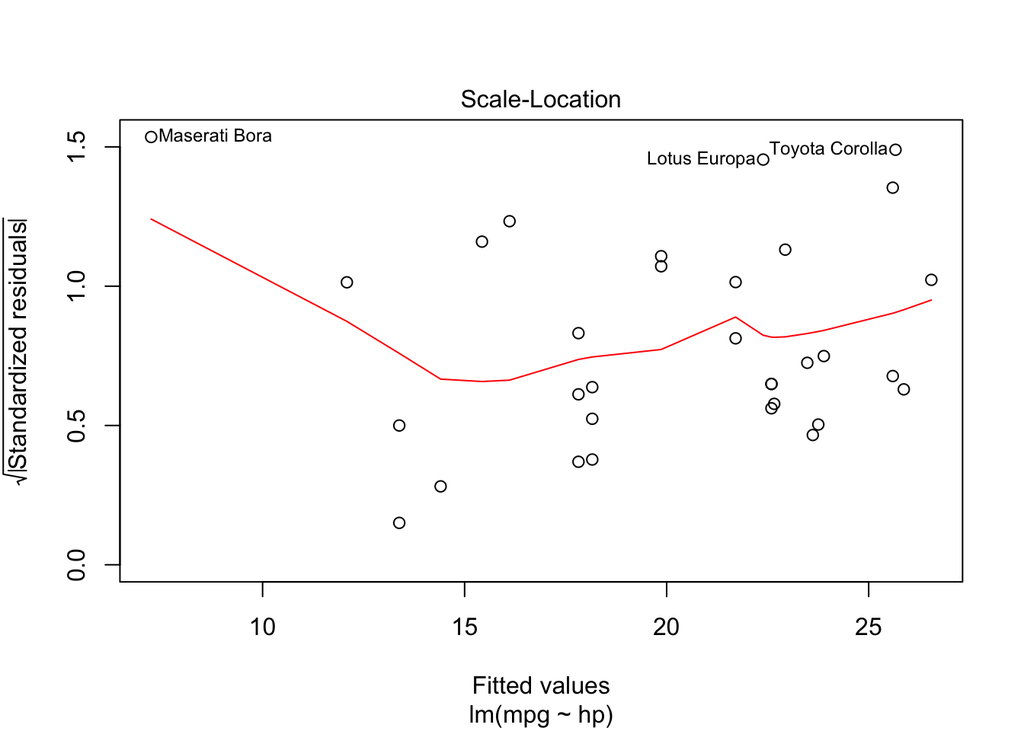

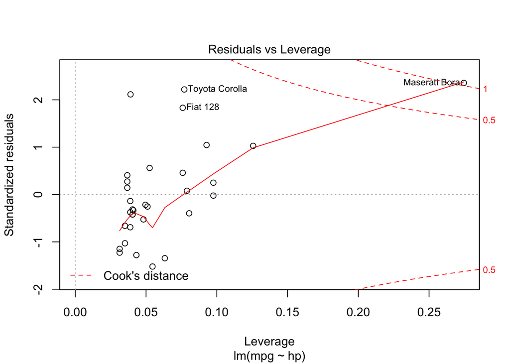

```r
plot(r1)
```

### Additional terms

How do we add more variables? What about transforming variables? Here is some of the formula syntax:

| Symbol | Example | Description |
| --- | --- | --- |
| `~` | `y ~ x1` | Defines the formula (necessary to create a formula object) |
| `+` | `y ~ x1 + x2` | Include the variable |
| `-` | `y ~ -1 +x1` | Delete a term, usually a 1 for the intercept |
| `:` | `y ~ x1 + x1:x2` | Interaction term |
| `*` | `y ~ x1*x2` | Interaction between the variables and each individually; same as `y ~ x1 + x2 + x1:x2` |
| `^` | `y ~ (x1, x2, x3)^3` | Include variables and all interactions, up to 3-way interactions |
| `I()` | `y ~ I(x1^2)` | Wrapper for transforming variables without having to create a new variable |
| `poly()` | `y ~ poly(x1, 2)` | Creates polynomial terms up to the degree specified |

We can use `I()` to transform variables as part of the formula syntax. We can add character or factor variables directly, and R will automatically create dummy (indicator) variables for us.

```r
r2 <- lm(mpg ~ hp + I(hp^2) + am + cyl, data=mtcars)
summary(r2)
```

```
##
## Call:
## lm(formula = mpg ~ hp + I(hp^2) + am + cyl, data = mtcars)
##
## Residuals:
##     Min      1Q  Median      3Q     Max
## -3.5346 -1.4905 -0.1394  1.4281  5.8274
##
## Coefficients:
##               Estimate Std. Error t value Pr(>|t|)
## (Intercept) 34.5193499  3.3413965  10.331 7.03e-11 ***
## hp          -0.1241475  0.0500586  -2.480   0.0197 *
## I(hp^2)      0.0002111  0.0001163   1.815   0.0806 .
## am           3.3892736  1.2783733   2.651   0.0133 *
## cyl         -0.5007040  0.7005650  -0.715   0.4809
## ---
## Signif. codes:  0 '***' 0.001 '**' 0.01 '*' 0.05 '.' 0.1 ' ' 1
##
## Residual standard error: 2.698 on 27 degrees of freedom
## Multiple R-squared:  0.8254, Adjusted R-squared:  0.7996
## F-statistic: 31.92 on 4 and 27 DF,  p-value: 7.088e-10
```

We added cylinders as a numeric variable above, but maybe it should be categorical? Also, a different way to specify the horsepower terms with `poly`

```r
r3 <- lm(mpg ~ poly(hp, 2, raw=TRUE) + am + I(factor(cyl)), data=mtcars)
summary(r3)
```

```
##
## Call:
## lm(formula = mpg ~ poly(hp, 2, raw = TRUE) + am + I(factor(cyl)),
##     data = mtcars)
##
## Residuals:
##     Min      1Q  Median      3Q     Max
## -3.9796 -1.6906 -0.2307  1.3885  5.3339
##
## Coefficients:
##                            Estimate Std. Error t value Pr(>|t|)
## (Intercept)              32.5082435  3.5362418   9.193 1.19e-09 ***
## poly(hp, 2, raw = TRUE)1 -0.1191294  0.0488505  -2.439  0.02188 *
## poly(hp, 2, raw = TRUE)2  0.0001835  0.0001146   1.602  0.12128
## am                        3.6759120  1.2581308   2.922  0.00711 **
## I(factor(cyl))6          -2.6100522  1.7052349  -1.531  0.13794
## I(factor(cyl))8          -1.4860065  2.7485108  -0.541  0.59334
## ---
## Signif. codes:  0 '***' 0.001 '**' 0.01 '*' 0.05 '.' 0.1 ' ' 1
##
## Residual standard error: 2.627 on 26 degrees of freedom
## Multiple R-squared:  0.8406, Adjusted R-squared:   0.81
## F-statistic: 27.42 on 5 and 26 DF,  p-value: 1.364e-09
```

Note that it picked one group to be the base comparison group, and created variables for the other two. If, instead of seeing offsets from a base group, we want indicator variables for all groups, we can drop the automatically added intercept term:

```r
r4 <- lm(mpg ~ -1 + poly(hp, 2, raw=TRUE) + am + I(factor(cyl)), data=mtcars)
summary(r4)
```

```
##
## Call:
## lm(formula = mpg ~ -1 + poly(hp, 2, raw = TRUE) + am + I(factor(cyl)),
##     data = mtcars)
##
## Residuals:
##     Min      1Q  Median      3Q     Max
## -3.9796 -1.6906 -0.2307  1.3885  5.3339
##
## Coefficients:
##                            Estimate Std. Error t value Pr(>|t|)
## poly(hp, 2, raw = TRUE)1 -0.1191294  0.0488505  -2.439  0.02188 *
## poly(hp, 2, raw = TRUE)2  0.0001835  0.0001146   1.602  0.12128
## am                        3.6759120  1.2581308   2.922  0.00711 **
## I(factor(cyl))4          32.5082435  3.5362418   9.193 1.19e-09 ***
## I(factor(cyl))6          29.8981913  4.4839344   6.668 4.50e-07 ***
## I(factor(cyl))8          31.0222370  5.4240165   5.719 5.09e-06 ***
## ---
## Signif. codes:  0 '***' 0.001 '**' 0.01 '*' 0.05 '.' 0.1 ' ' 1
##
## Residual standard error: 2.627 on 26 degrees of freedom
## Multiple R-squared:  0.9872, Adjusted R-squared:  0.9843
## F-statistic: 334.7 on 6 and 26 DF,  p-value: < 2.2e-16
```

This is also useful if we need to constrain the fitted line to go through the origin.

We can plot fitted values for each variable:

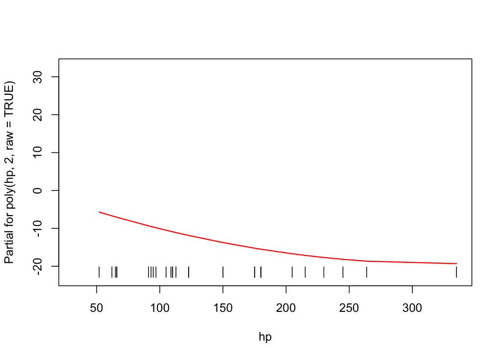

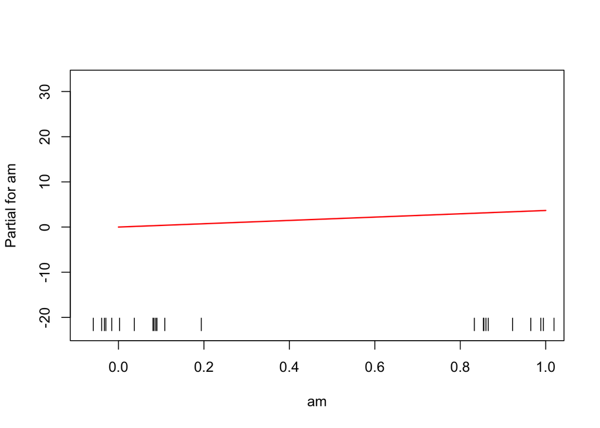

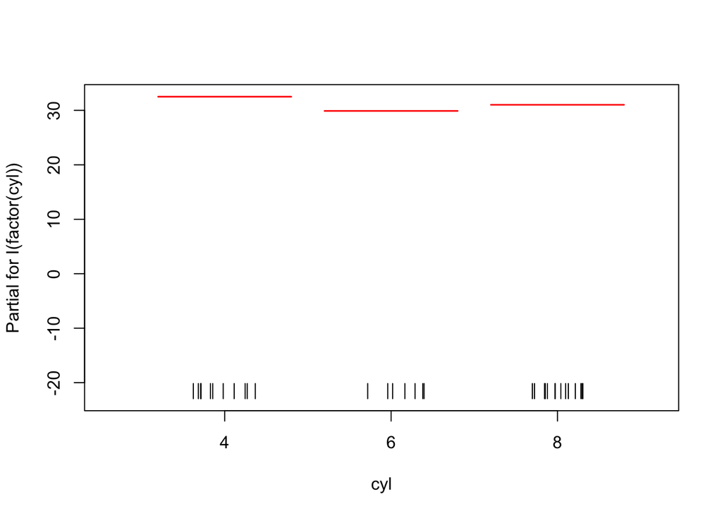

```r
termplot(r4, rug=TRUE)
```

[More on `termplot`](http://www.clayford.net/statistics/tag/termplot/)

### Predicting values

If we want to predict new values from our fitted model, we can supply a data frame with column names matching the data we used to fit the model. Let’s see how changing hp affects the model. Hold transmission and cylinders at constant values.

```r
newvals <- data.frame(hp=seq(50,250,10),
                      am=0,
                      cyl=4)
mpg_predict<- predict(r4, newvals)
mpg_predict
```

```
##        1        2        3        4        5        6        7        8
## 27.01060 26.02120 25.06849 24.15250 23.27321 22.43063 21.62475 20.85558
##        9       10       11       12       13       14       15       16
## 20.12312 19.42737 18.76832 18.14597 17.56034 17.01141 16.49918 16.02367
##       17       18       19       20       21
## 15.58486 15.18275 14.81736 14.48867 14.19668
```

Note that I don’t have to transform `hp` or `cyl` before calling `predict`.

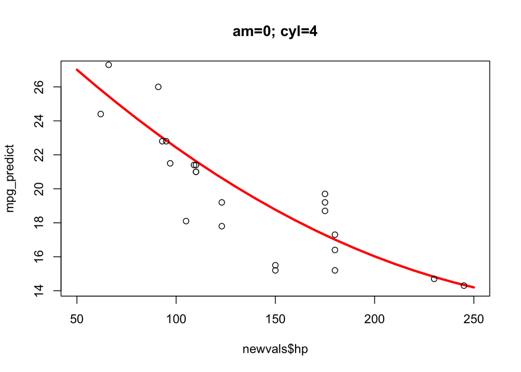

```r
plot(mpg_predict ~ newvals$hp,
     type="l", lwd=3, col="red", # line style
     main="am=0; cyl=4") # making note of other values
points(mtcars$mpg~mtcars$hp)
```

# Probability Distributions

R knows about a lot of probability distributions:

```r
help(Distributions)
```

For each distribution, there are 4 function: dxxx, pxxx, qxxx and rxxx, where xxx is the name for the distribution. Take the normal distribution as an example.

By default, the normal distribution functions use the distribution with mean=0 and standard deviation (sd)=1. You can change these for different variations on the distribution.

## `dnorm`

First, there is a function to get the density of the probability distribution (the [PDF](https://en.wikipedia.org/wiki/Probability_density_function)):

```r
vals<-seq(-4, 4, .2) # this makes a vector with a sequence of numbers from -4 to 4 in it
data.frame(vals=vals, pdf=dnorm(vals))
```

```
##    vals          pdf
## 1  -4.0 0.0001338302
## 2  -3.8 0.0002919469
## 3  -3.6 0.0006119019
## 4  -3.4 0.0012322192
## 5  -3.2 0.0023840882
## 6  -3.0 0.0044318484
## 7  -2.8 0.0079154516
## 8  -2.6 0.0135829692
## 9  -2.4 0.0223945303
## 10 -2.2 0.0354745928
## 11 -2.0 0.0539909665
## 12 -1.8 0.0789501583
## 13 -1.6 0.1109208347
## 14 -1.4 0.1497274656
```

[output cut: 27 more lines]

Looking at the data, the pdf peaks at 0 (the mean), and decreases symetrically away from 0. Plot this:

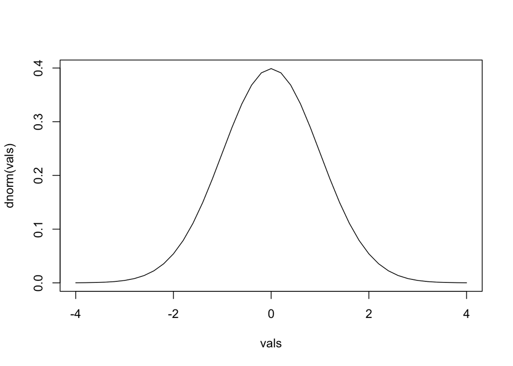

```r
plot(dnorm(vals) ~ vals, type="l")
```

It looks like what you expect for the normal distribution. `dnorm` is mostly commonly used for drawing the distribution – you don’t usually need to compute the value of the PDF at a specific point otherwise.

## `pnorm`

`pnorm` tells us how likely it is (the probability) that a random draw from the distribution would be a value less than or equal to the number supplied – this is the area under the PDF curve. The return value will range between 0 and 1:

```r
vals<-seq(-3,3,.2)
data.frame(vals=vals, prob=pnorm(vals))
```

```
##    vals        prob
## 1  -3.0 0.001349898
## 2  -2.8 0.002555130
## 3  -2.6 0.004661188
## 4  -2.4 0.008197536
## 5  -2.2 0.013903448
## 6  -2.0 0.022750132
## 7  -1.8 0.035930319
## 8  -1.6 0.054799292
## 9  -1.4 0.080756659
## 10 -1.2 0.115069670
## 11 -1.0 0.158655254
## 12 -0.8 0.211855399
## 13 -0.6 0.274253118
## 14 -0.4 0.344578258
```

[output cut: 17 more lines]

It’s always increasing (since as you move right on the number line you’re always increasing the probability that a random draw would be less than or equal to the value), and `pnorm(0)` is 0.5 – since there’s a 50/50 chance that a random draw would be to the left of the mean. If you plot the results of `pnorm`, you get the [CDF](https://en.wikipedia.org/wiki/Cumulative_distribution_function):

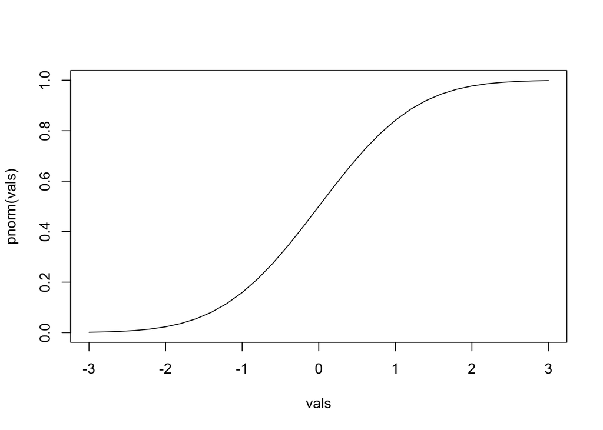

```r
plot(pnorm(vals)~vals, type="l")
```

You would use pnorm when looking up the probability of getting a particular value (such as a test statistic that follows a normal distribution). You can get the probability of a random draw being to the right of the specified value instead with `lower.tail`:

```r
pnorm(1.6)
pnorm(1.6, lower.tail=FALSE)
```

```
## [1] 0.9452007
## [1] 0.05479929
```

## `qnorm`

`qnorm` is the opposite of `pnorm` – it tells you what value you need such that you have the supplied probability of a random draw being less than or equal to (to the left of) that value from the distribution. For example, if you want to know what value you need such that there’s a 95% chance that a random draw would be less than or equal to the number:

```r
qnorm(0.95)
```

```
## [1] 1.644854
```

You need a value of 1.64. Random draws from a normal distribution with mean=0 and standard deviation=1 will be less than or equal to 1.64 95% of the time.

The value you supply to `qnorm` must be between 0 and 1. There’s no limit on the range of the return value.

Again, `pnorm` and `qnorm` are opposites:

```r
qnorm(pnorm(2))
pnorm(qnorm(.8))
```

```
## [1] 2
## [1] 0.8
```

## `rnorm`

The last function is to generate random draws from the distribution. Tell it how many random draws you want:

```r
rnorm(10)
```

```
##  [1]  0.0889260 -0.3651270 -1.2548008  1.6642913 -0.6697182  0.6510435
##  [7] -0.7015563 -1.5366659  0.6854529  0.2880859
```

If you want to make sure we get the same sequence of random numbers each time (or as someone else), you can set the seed with any integer value:

```r
set.seed(12345)
rnorm(10)
```

```
##  [1]  0.5855288  0.7094660 -0.1093033 -0.4534972  0.6058875 -1.8179560
##  [7]  0.6300986 -0.2761841 -0.2841597 -0.9193220
```

This is useful for running simulations when you need to sample from a distribution.